# hw.5.md

## HW MD 5

```r
library(tidyverse)
twitch_data <- read_csv("https://raw.githubusercontent.com/vaiseys/dav-course/main/Data/twitchdata-update.csv")
```

```r
library(janitor)
twitch_data <- clean_names(twitch_data)

# Inspect new names
colnames(twitch_data)
```

```
 [1] "channel"             "watch_time_minutes"  "stream_time_minutes"
 [4] "peak_viewers"        "average_viewers"     "followers"
 [7] "followers_gained"    "views_gained"        "partnered"
[10] "mature"              "language"
```

```r
view_follow <- twitch_data |>
  select(channel, followers, average_viewers)
view_follow
```

```
# A tibble: 1,000 × 3
   channel    followers average_viewers
   <chr>          <dbl>           <dbl>
 1 xQcOW        3246298           27716
 2 summit1g     5310163           25610
 3 Gaules       1767635           10976
 4 ESL_CSGO     3944850            7714
 5 Tfue         8938903           29602
 6 Asmongold    1563438           42414
 7 NICKMERCS    4074287           24181
 8 Fextralife    508816           18985
 9 loltyler1    3530767           22381
10 Anomaly      2607076           12377
# ℹ 990 more rows
```

```r
summary(view_follow)
```

```
   channel            followers       average_viewers
 Length:1000        Min.   :   3660   Min.   :   235
 Class :character   1st Qu.: 170546   1st Qu.:  1458
 Mode  :character   Median : 318063   Median :  2425
                    Mean   : 570054   Mean   :  4781
                    3rd Qu.: 624332   3rd Qu.:  4786
                    Max.   :8938903   Max.   :147643
```

The mean of average viewers is 4,781, and the mean of followers is 570,054. The minimum or lowest number of followers is 3,660, and the largest number of followers is 8,938,903.

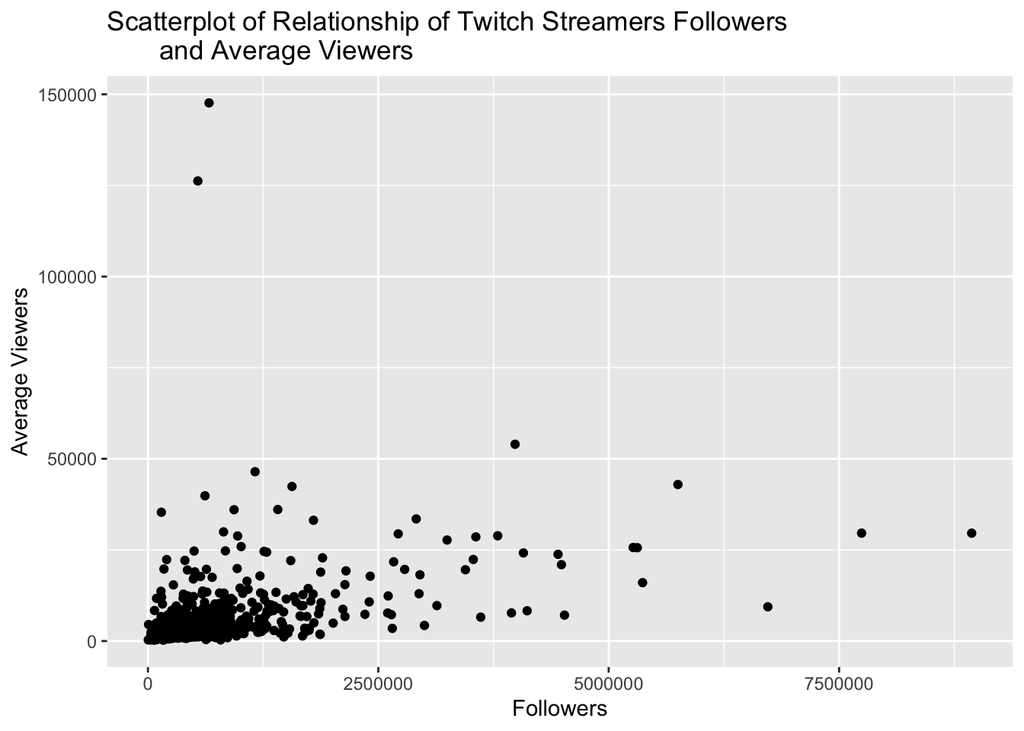

```r
ggplot(data = view_follow,
       mapping = aes(x = followers, y = average_viewers)) +
  geom_point() +
  labs(x = "Followers",
       y = "Average Viewers",
       title = "Scatterplot of Relationship of Twitch Streamers Followers
       and Average Viewers")
```

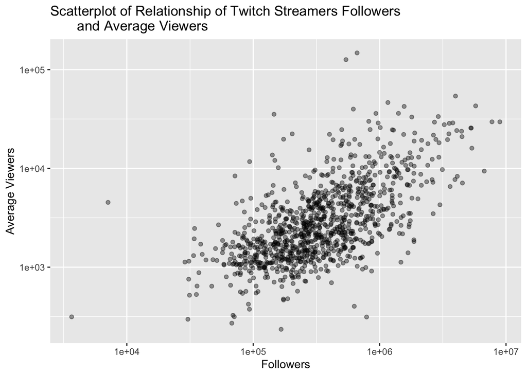

```r
ggplot(data = view_follow,
       mapping = aes(x = followers, y = average_viewers)) +
  geom_jitter(alpha = 0.4) +
  scale_x_log10() +
  scale_y_log10() +
  labs(x = "Followers",
       y = "Average Viewers",
       title = "Scatterplot of Relationship of Twitch Streamers Followers
       and Average Viewers")
```

Using the scale_x_log() and the scale_y_log(), I can visualize the data more clearly as all the points aren’t condensed into one corner of the graph. This also helps display a clearer image of the relationship, displaying a positive correlation between followers and viewers.

```r
twitch_data <- twitch_data %>%
  mutate(log_viewers = log10(average_viewers),
         log_followers = log10(followers))
```

## Question 2

```r
fit1 <- lm(log_viewers ~
             log_followers,
           data = twitch_data)
```

```r
fit1 <- lm(log_viewers ~
             log_followers,
           data = twitch_data)
broom::tidy(fit1)
```

```
# A tibble: 2 × 5
  term          estimate std.error statistic   p.value
  <chr>            <dbl>     <dbl>     <dbl>     <dbl>
1 (Intercept)      0.198    0.125       1.58 1.15e-  1
2 log_followers    0.588    0.0226     26.0  1.69e-114
```

```r
fit1
```

```
Call:
lm(formula = log_viewers ~ log_followers, data = twitch_data)

Coefficients:
  (Intercept)  log_followers
       0.1978         0.5885
```

$$1.1^{0.59} = 1.0578$$

Every 10% increase in followers results in a 5.78 % increase in average_viewers.

## Question 3

```r
library(broom)

pred_data <- augment(fit1)

# glimpse our new data
glimpse(pred_data)
```

```
Rows: 1,000
Columns: 8
$ log_viewers   <dbl> 4.442731, 4.408410, 4.040444, 3.887280, 4.471321, 4.6275…
$ log_followers <dbl> 6.511388, 6.725108, 6.247393, 6.596030, 6.951284, 6.1940…
$ .fitted       <dbl> 4.029761, 4.155534, 3.874400, 4.079572, 4.288638, 3.8430…
$ .resid        <dbl> 0.4129697, 0.2528757, 0.1660436, -0.1922928, 0.1826833, …
$ .hat          <dbl> 0.006194481, 0.008694557, 0.003782169, 0.007126066, 0.01…
$ .sigma        <dbl> 0.3085580, 0.3087321, 0.3087919, 0.3087764, 0.3087820, 0…
$ .cooksd       <dbl> 0.0056128779, 0.0029688873, 0.0005513456, 0.0014026033, …
$ .std.resid    <dbl> 1.3420109, 0.8227954, 0.5389316, -0.6251793, 0.5953620, …
```

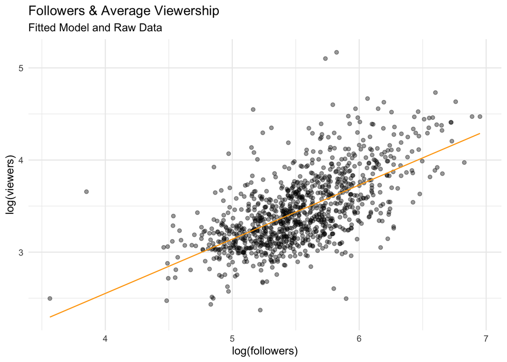

```r
pred_data %>%
  ggplot(aes(x = log_followers,
             y = log_viewers)) +
  geom_jitter(alpha = 0.4) +
  geom_line(aes(x = log_followers,
                y = .fitted),
            col = "orange") +
  theme_minimal() +
  labs(subtitle = "Fitted Model and Raw Data",
       title = "Followers & Average Viewership",
       x = "log(followers)",
       y = "log(viewers)")
```

I think the model above does describe the relationship well as it accurately follows the relationship between followers and average viewers.

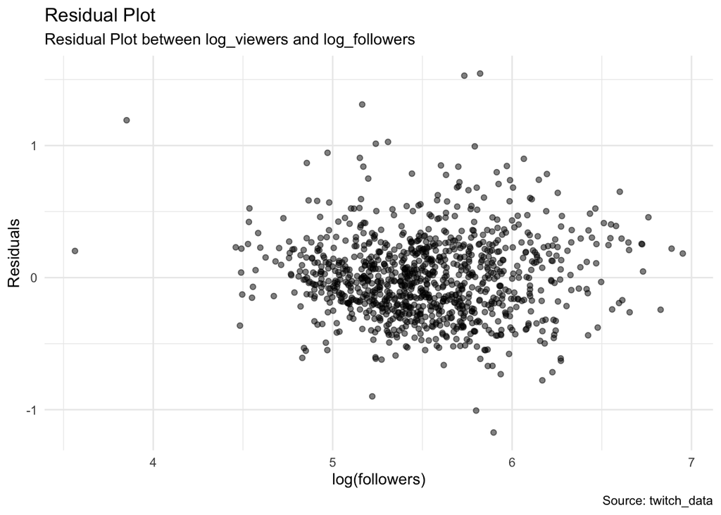

```r
pred_data |>
  ggplot(aes(x = log_followers,
             y = .resid)) +
  geom_jitter(alpha = 0.5) +
  theme_minimal() +
  labs(subtitle = "Residual Plot between log_viewers and log_followers",
       title = "Residual Plot",
       x = "log(followers)",
       y = "Residuals",
       caption = "Source: twitch_data")
```

Looking at the residual plot, we can see that model is an appropriate fit. Seeing that the points have no pattern and that they all center around 0 residual, there is little difference between the averages. However, there are some outliers that range from -1 to 1.5.

## Question 4

```r
language_viewer <- twitch_data |>
  select(channel, language, average_viewers)

language_viewer
```

```
# A tibble: 1,000 × 3
   channel    language   average_viewers
   <chr>      <chr>                <dbl>
 1 xQcOW      English              27716
 2 summit1g   English              25610
 3 Gaules     Portuguese           10976
 4 ESL_CSGO   English               7714
 5 Tfue       English              29602
 6 Asmongold  English              42414
 7 NICKMERCS  English              24181
 8 Fextralife English              18985
 9 loltyler1  English              22381
10 Anomaly    English              12377
# ℹ 990 more rows
```

Looking at the raw data, we can clearly see that the English language dominates the streaming scene.

Now I will look at the suammaries of the variables.

```r
summary(language_viewer)
```

```
   channel            language         average_viewers
 Length:1000        Length:1000        Min.   :   235
 Class :character   Class :character   1st Qu.:  1458
 Mode  :character   Mode  :character   Median :  2425
                                       Mean   :  4781
                                       3rd Qu.:  4786
                                       Max.   :147643
```

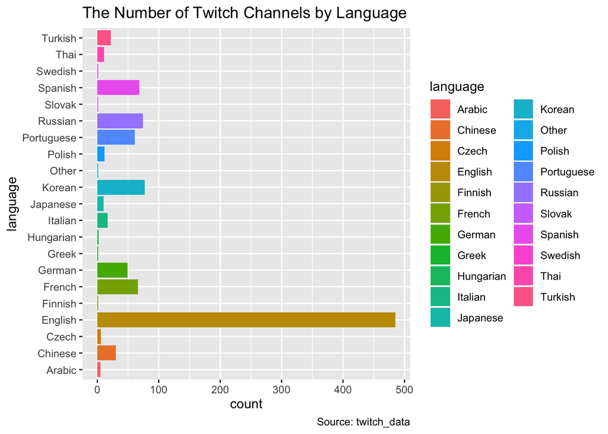

```r
ggplot(data = language_viewer,
       mapping = aes(x = language,
                     fill = language)) +
  geom_bar() +
  coord_flip() +
  labs(title = "The Number of Twitch Channels by Language",
       caption = "Source: twitch_data")
```

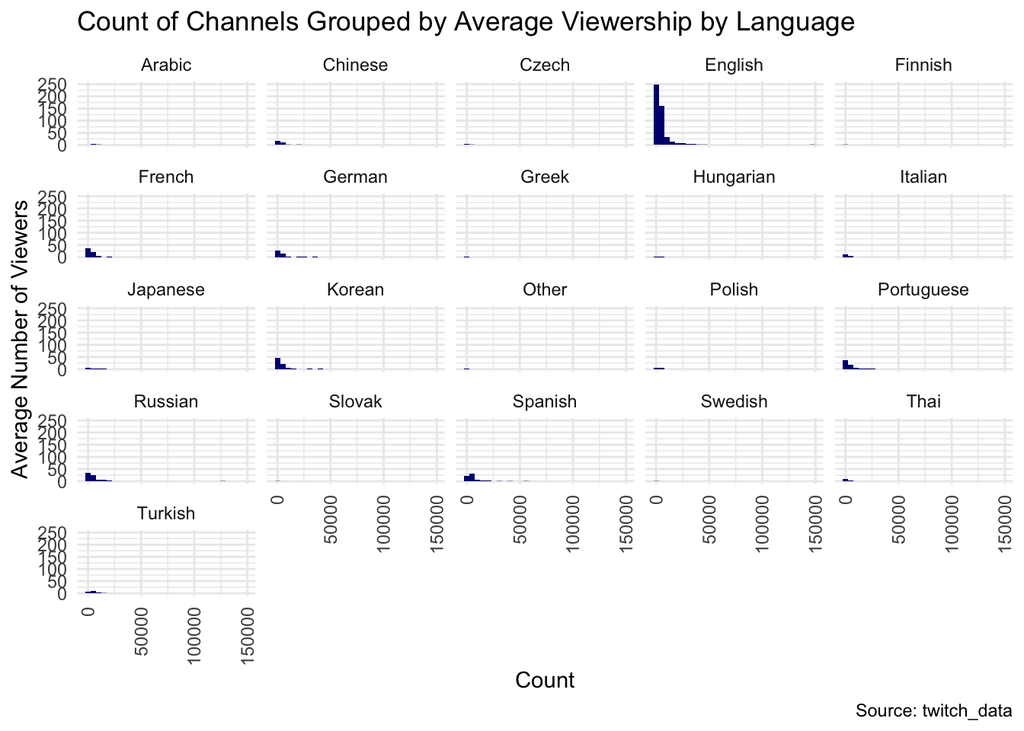

```r
ggplot(data = language_viewer,
       mapping = aes(x = average_viewers)) +
  geom_histogram(fill = "navy") +
  facet_wrap(~language) +
  theme_minimal() + theme(axis.text.x = element_text(angle = 90,
                                                     vjust = 0.5,
                                                     hjust=1)) +
  labs(x = "Count", y = "Average Number of Viewers", title = "Count of Channels Grouped by Average Viewership by Language", caption = "Source: twitch_data")
```

Using the two graphs above, we can clearly see that the English language has the most channels, as expected in your prediction.

## Question 5

```r
fit2 <- lm(average_viewers ~ language,
           data = language_viewer)

broom::tidy(fit2)
```

```
# A tibble: 21 × 5
   term              estimate std.error statistic p.value
   <chr>                <dbl>     <dbl>     <dbl>   <dbl>
 1 (Intercept)          5682.     3788.     1.50    0.134
 2 languageChinese     -2257.     4092.    -0.552   0.581
 3 languageCzech       -3855.     5129.    -0.751   0.453
 4 languageEnglish      -569.     3808.    -0.150   0.881
 5 languageFinnish     -4655.     9279.    -0.502   0.616
 6 languageFrench      -2176.     3929.    -0.554   0.580
 7 languageGerman      -1404.     3977.    -0.353   0.724
 8 languageGreek       -3721.     9279.    -0.401   0.688
 9 languageHungarian   -3542.     7087.    -0.500   0.617
10 languageItalian     -3477.     4310.    -0.807   0.420
# ℹ 11 more rows
```

```r
fit2
```

```
Call:
lm(formula = average_viewers ~ language, data = language_viewer)

Coefficients:
       (Intercept)     languageChinese       languageCzech     languageEnglish
            5682.2             -2257.4             -3854.5              -569.4
   languageFinnish      languageFrench      languageGerman       languageGreek
           -4655.2             -2175.7             -1404.0             -3721.2
 languageHungarian     languageItalian    languageJapanese      languageKorean
           -3541.7             -3476.7              -919.6             -1768.3
     languageOther      languagePolish  languagePortuguese     languageRussian
           -4533.2             -2777.0             -1881.3               912.0
    languageSlovak     languageSpanish     languageSwedish        languageThai
           -3610.2               767.5             -4655.2             -3670.8
   languageTurkish
            -921.3
```

```r
twitch_data <- twitch_data %>%
  mutate(language = as.factor(language),
         language = relevel(language, ref = "English"))
```

## Question 6

```r
pred_data_2 <- augment(fit2)
```

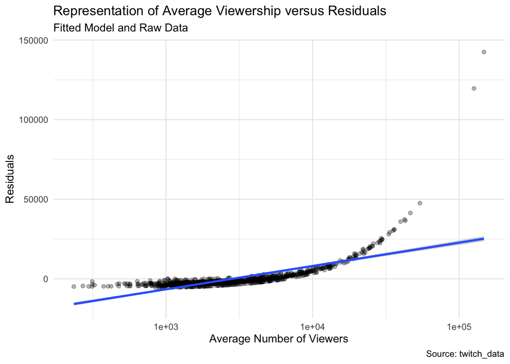

```r
pred_data_2 %>% ggplot(aes(x = average_viewers,
                           y = .resid)) +
geom_jitter(alpha = 0.3) +
geom_smooth(method = lm) +
scale_x_log10() +
theme_minimal() +
labs(subtitle = "Fitted Model and Raw Data", title = "Representation of Average Viewership versus Residuals", x = "Average Number of Viewers", y = "Residuals", caption = "Source: twitch_data")
```

The pair of points that miss the model are from the channel dota2i, both the English and Russian versions. They are high above the line of fit due to their high residuals.